# Actividad_03

# **7. Realice la validación de los supuestos del modelo por medio de gráficos apropiados, interpretarlos y sugerir posibles soluciones si se violan algunos de ellos. Utilice las pruebas de hipótesis para la validación de supuestos y compare los resultados con lo observado en los gráficos asociados.**

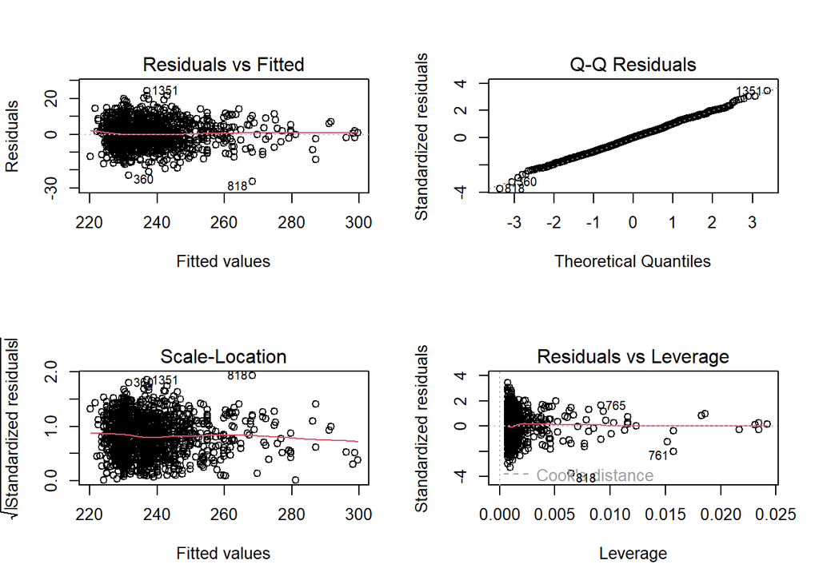

```r
par (mfrow=c(2,2))
plot(modelo_regresion1)
```

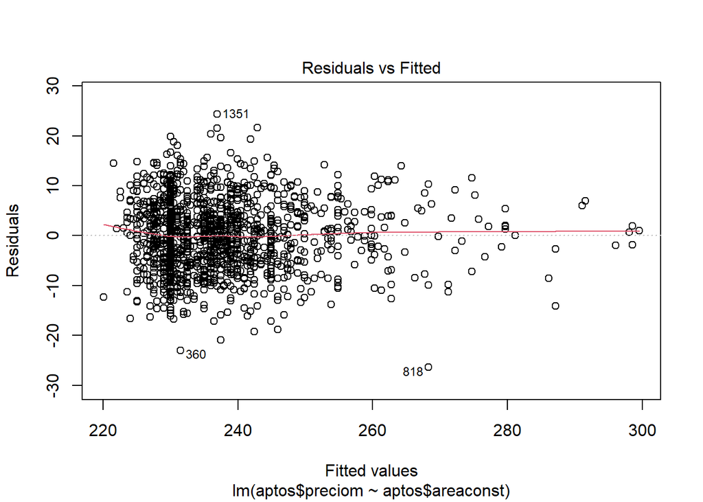

```r
# Gráfico de Residuales vs. Valores Ajustados
plot(modelo_regresion1, which = 1)
```

```r
durbinWatsonTest(modelo_regresion1)
```

```
##  lag Autocorrelation D-W Statistic p-value
##    1      -0.0114037      2.022234   0.662
##  Alternative hypothesis: rho != 0
```

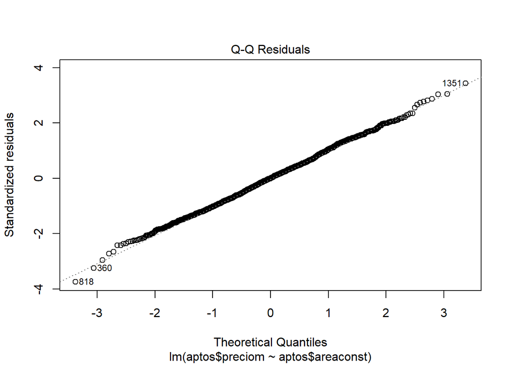

```r
# Gráfico de Residuales vs. Orden
plot(modelo_regresion1, which = 2)
```

```r
# Prueba de Ljung-Box
library(astsa)
Box.test(resid(modelo_regresion1), lag = 20, type = "Ljung")
```

```
##
##  Box-Ljung test
##
## data:  resid(modelo_regresion1)
## X-squared = 19.343, df = 20, p-value = 0.4997
```

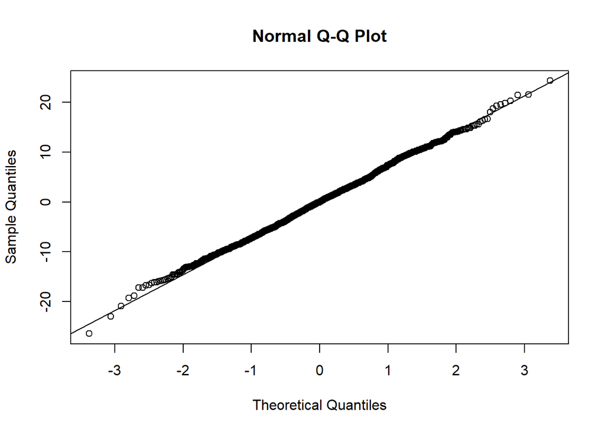

```r
# Gráfico Q-Q (Quantile-Quantile)
qqnorm(resid(modelo_regresion1))
qqline(resid(modelo_regresion1))
```

Para cada gráfica los hallazgos son los siguientes:

## **7.1. Gráfico de Linealidad**

La gráfica de Residuals vs Fitted permite evaluar si los residuales (errores) del modelo tienen una relación sistemática con los valores ajustados (predichos).